# Software Bug Prediction

### Dataset:

The dataset is collected at the University of Geneva in Switzerland related to the bug prediction dataset. It contains data about the following software systems:

```
- Eclipse JDT Core
- Eclipse PDE UI
- Equinox Framework
- Lucene
- Mylyn
```

### Objective:

Software success depends heavily on the ability of maintaining the software and ensuring that the software is released with minimal number of issues. Knowing in advance an estimation of possibile bugs in the software will mitagate some of the risks after the software is released. Our main objective is to be able to predict in advance the number of bugs in the software using the software data itself such as the number of lines of code, number of methods, number of attributes, and other important software properties. This is an overview of our objectives in details:

- Data Analysis
- Data preprocessing
- Data visualization
- Advanced EDA and visulaization using ML/D-reduction algorithms
- hyper-parameter tuning and solving the imbalance problem
  - Classifying data where the classes are: no bugs, 1 bug, or > 2 bugs
  - Classifying data where the classes are: no bugs, > 0 bugs

### Outline:

- import
- data cleaning
- EDA and visualization
  - descriptive statistics
  - correlation matrix
  - feature importance (Lasso)
  - feature importance (RFC)
  - kernal density estimation
  - 3D scatter cross plots
  - UMAP dimensionality reduction
  - PCA dimensionality reduction
  - clustering analysis
- Base Line Classifier
  - Accuacy
  - ROC
  - F-1 Score
  - Confusion Matrix
  - Area Under the Curve of ROC Viz
- first stage modeling
  - hyper-parameter tuning model optimization
  - dimensionality reduction
- evaluation
  - Accuacy
  - ROC
  - F-1 Score
  - Confusion Matrix
  - Area Under the Curve of ROC Viz
- second stage modeling (data-driven model optimization to tackle imbalance)
  - Under Sampling
  - Over Sampling
  - Feature Selection
- evaluation
  - Accuacy
  - ROC
  - F-1 Score
- models quality metrics table
  - Multi
    - Accuacy (All and Best)
    - ROC (All and Best)
    - F-1 Score (All and Best)
  - Binary
    - Accuacy (All and Best)
    - ROC (All and Best)
    - F-1 Score (All and Best)

```python
import pandas as pd
import numpy as np
import random as rnd

import seaborn as sns
import matplotlib.pyplot as plt
plt.rcParams["figure.figsize"] = (8, 5)

from sklearn.ensemble import BaggingClassifier

from sklearn.linear_model import LogisticRegression
from sklearn.svm import SVC, LinearSVC
from sklearn.ensemble import RandomForestClassifier
from sklearn.neighbors import KNeighborsClassifier
from sklearn.naive_bayes import GaussianNB
from sklearn.linear_model import Perceptron
from sklearn.linear_model import SGDClassifier
from sklearn.tree import DecisionTreeClassifier
from sklearn.preprocessing import StandardScaler
from sklearn.linear_model import Lasso
from sklearn.pipeline import Pipeline
from sklearn.model_selection import GridSearchCV
from sklearn.model_selection import StratifiedKFold

from sklearn.ensemble import AdaBoostClassifier


from sklearn.metrics import accuracy_score, roc_auc_score, roc_curve, auc, confusion_matrix, f1_score

from sklearn.preprocessing import LabelBinarizer


from mpl_toolkits.mplot3d import Axes3D
from sklearn.cluster import KMeans
from sklearn.dummy import DummyClassifier
from sklearn.decomposition import PCA
from sklearn.mixture import GaussianMixture
import umap
```

# Import

```python
eclipse_jdt = pd.read_csv("./data/Eclipse_ JDT_Core_single-version-ck-oo_bugs_only.csv")
eclipse_pdt = pd.read_csv("./data/Eclipse_PDE_UI_single-version-ck-oo_bug_only.csv")
equinox = pd.read_csv("./data/Equinox_Framework_single-version-ck-oo_bug_only.csv")
lucene = pd.read_csv("./data/Lucene_single-version-ck-oo_bug_only.csv")
mylyn = pd.read_csv("./data/Mylyn_single-version-ck-oo_bug_only.csv")
```

# Preprocessing & Analysis

```python
print("NaNs in eclipse_jdt", np.sum(np.sum(eclipse_jdt.isna(), axis=0)) )
print("NaNs in eclipse_pdt", np.sum(np.sum(eclipse_pdt.isna(), axis=0)) )
print("NaNs in equinox", np.sum(np.sum(equinox.isna(), axis=0)) )
print("NaNs in lucene", np.sum(np.sum(lucene.isna(), axis=0)) )
print("NaNs in mylyn", np.sum(np.sum(mylyn.isna(), axis=0)) )

# drop nans
eclipse_pdt.dropna(axis = 1, inplace=True)
equinox.dropna(axis = 1, inplace=True)
lucene.dropna(axis = 1, inplace=True)
mylyn.dropna(axis = 1, inplace=True)
```

```
NaNs in eclipse_jdt 0
NaNs in eclipse_pdt 5988
NaNs in equinox 1296
NaNs in lucene 2764
NaNs in mylyn 7448
```

### Note:

All Nans are added columns due to added commas (seperators) in each row

```python
print("Data Shapes:", eclipse_jdt.shape, eclipse_pdt.shape, equinox.shape, lucene.shape, mylyn.shape)
df = pd.concat([eclipse_jdt, eclipse_pdt, equinox, lucene, mylyn], ignore_index=True)
df.columns = df.columns.str.replace(' ', '')
print("Full dataframe shape:",df.shape, '\n')
print("Predictors:")
for name in df.columns.values[1:18].tolist():
    print(name, end=', ')
print("\n\nPredictable:", df.columns.values[18])
df.head()
```

```
Data Shapes: (997, 20) (1497, 20) (324, 20) (691, 20) (1862, 20)
Full dataframe shape: (5371, 20)

Predictors:
cbo, dit, fanIn, fanOut, lcom, noc, numberOfAttributes, numberOfAttributesInherited, numberOfLinesOfCode, numberOfMethods, numberOfMethodsInherited, numberOfPrivateAttributes, numberOfPrivateMethods, numberOfPublicAttributes, numberOfPublicMethods, rfc, wmc,

Predictable: bugs
```

|  | classname | cbo | dit | fanIn | fanOut | lcom | noc | numberOfAttributes | numberOfAttributesInherited | numberOfLinesOfCode | numberOfMethods | numberOfMethodsInherited | numberOfPrivateAttributes | numberOfPrivateMethods | numberOfPublicAttributes | numberOfPublicMethods | rfc | wmc | bugs |  |
| --- | --- | --- | --- | --- | --- | --- | --- | --- | --- | --- | --- | --- | --- | --- | --- | --- | --- | --- | --- | --- |
| 0 | org::eclipse::jdt::internal::core::search::ind... | 9 | 2 | 1 | 9 | 15 | 0 | 1 | 8 | 122 | 6 | 19 | 0 | 0 | 1 | 5 | 34 | 20 | 0 |  |
| 1 | org::eclipse::jdt::internal::compiler::codegen... | 1 | 1 | 1 | 0 | 0 | 0 | 2 | 0 | 4 | 1 | 8 | 0 | 0 | 2 | 1 | 1 | 1 | 0 |  |
| 2 | org::eclipse::jdt::internal::compiler::ast::AS... | 114 | 1 | 102 | 18 | 190 | 6 | 131 | 249 | 484 | 20 | 8 | 0 | 1 | 3 | 19 | 156 | 176 | 1 |  |
| 3 | org::eclipse::jdt::internal::compiler::lookup:... | 5 | 6 | 1 | 4 | 10 | 0 | 0 | 61 | 33 | 5 | 207 | 0 | 0 | 0 | 4 | 18 | 12 | 0 |  |
| 4 | org::eclipse::jdt::internal::eval::CodeSnippet... | 23 | 2 | 1 | 22 | 820 | 0 | 7 | 416 | 673 | 41 | 8 | 0 | 2 | 7 | 1 | 174 | 115 | 0 |  |

```python
df.describe()
```

|  | cbo | dit | fanIn | fanOut | lcom | noc | numberOfAttributes | numberOfAttributesInherited | numberOfLinesOfCode | numberOfMethods | numberOfMethodsInherited | numberOfPrivateAttributes | numberOfPrivateMethods | numberOfPublicAttributes | numberOfPublicMethods | rfc | wmc | bugs |
| --- | --- | --- | --- | --- | --- | --- | --- | --- | --- | --- | --- | --- | --- | --- | --- | --- | --- | --- |
| count | 5371.000000 | 5371.000000 | 5371.000000 | 5371.000000 | 5371.000000 | 5371.000000 | 5371.000000 | 5371.000000 | 5371.000000 | 5371.000000 | 5371.000000 | 5371.000000 | 5371.000000 | 5371.000000 | 5371.000000 | 5371.000000 | 5371.000000 | 5371.000000 |
| mean | 9.650717 | 1.948985 | 4.077825 | 5.808229 | 131.440328 | 0.548687 | 5.648110 | 20.607522 | 119.126233 | 9.465649 | 25.673245 | 2.701545 | 1.515733 | 1.588903 | 6.271272 | 47.397133 | 28.291380 | 0.259914 |
| std | 15.430910 | 1.339559 | 12.763334 | 7.413065 | 1419.297581 | 2.320663 | 32.421878 | 75.447749 | 305.121926 | 13.519683 | 40.646291 | 5.005445 | 4.259624 | 30.836387 | 10.583760 | 100.978959 | 69.140371 | 0.880067 |
| min | 0.000000 | 1.000000 | 0.000000 | 0.000000 | 0.000000 | 0.000000 | 0.000000 | 0.000000 | 0.000000 | 0.000000 | 0.000000 | 0.000000 | 0.000000 | 0.000000 | 0.000000 | 0.000000 | 0.000000 | 0.000000 |
| 25% | 3.000000 | 1.000000 | 1.000000 | 1.000000 | 3.000000 | 0.000000 | 1.000000 | 0.000000 | 18.000000 | 3.000000 | 7.000000 | 0.000000 | 0.000000 | 0.000000 | 2.000000 | 8.000000 | 4.000000 | 0.000000 |
| 50% | 6.000000 | 1.000000 | 1.000000 | 3.000000 | 15.000000 | 0.000000 | 2.000000 | 0.000000 | 47.000000 | 6.000000 | 12.000000 | 1.000000 | 0.000000 | 0.000000 | 4.000000 | 21.000000 | 11.000000 | 0.000000 |
| 75% | 11.000000 | 2.000000 | 3.000000 | 8.000000 | 55.000000 | 0.000000 | 5.000000 | 2.000000 | 115.000000 | 11.000000 | 30.000000 | 3.000000 | 1.000000 | 0.000000 | 7.000000 | 51.000000 | 27.000000 | 0.000000 |
| max | 362.000000 | 9.000000 | 355.000000 | 93.000000 | 81003.000000 | 49.000000 | 2169.000000 | 563.000000 | 7509.000000 | 403.000000 | 602.000000 | 103.000000 | 111.000000 | 2168.000000 | 387.000000 | 2603.000000 | 1680.000000 | 28.000000 |

### Note:

- Values in columns are distributed with high standard deviation compared to others -> Scaling is needed if a distance-based model is used, but not now on the whole dataset to prevent data leakage.
- We do not need confusing variables such as the class name; We can use it as an index or discard it.

```python
# Shuffle data before removing classname to keep mapping
df = df.sample(frac=1.0)

# We do not need confusing variables such as the class name; We can use it as an index or leave it.
X = df.iloc[:, 1:-2]
y = df["bugs"]

print("X:", X.shape)
print("y:", y.shape)
```

```
X: (5371, 17)
y: (5371,)
```

```python
X.head()
```

|  | cbo | dit | fanIn | fanOut | lcom | noc | numberOfAttributes | numberOfAttributesInherited | numberOfLinesOfCode | numberOfMethods | numberOfMethodsInherited | numberOfPrivateAttributes | numberOfPrivateMethods | numberOfPublicAttributes | numberOfPublicMethods | rfc | wmc |
| --- | --- | --- | --- | --- | --- | --- | --- | --- | --- | --- | --- | --- | --- | --- | --- | --- | --- |
| 5131 | 13 | 2 | 2 | 11 | 105 | 0 | 7 | 1 | 104 | 15 | 33 | 7 | 1 | 0 | 13 | 39 | 19 |
| 44 | 3 | 6 | 1 | 2 | 21 | 0 | 1 | 384 | 39 | 7 | 79 | 0 | 0 | 0 | 7 | 14 | 11 |
| 807 | 2 | 1 | 2 | 0 | 1 | 0 | 13 | 0 | 42 | 2 | 8 | 0 | 0 | 13 | 2 | 2 | 10 |
| 623 | 19 | 1 | 18 | 1 | 231 | 0 | 20 | 0 | 95 | 22 | 8 | 0 | 1 | 0 | 21 | 48 | 34 |
| 1419 | 10 | 2 | 2 | 8 | 10 | 0 | 1 | 0 | 53 | 5 | 11 | 1 | 0 | 0 | 2 | 31 | 14 |

```python
X = df.iloc[:, 1:-2]
y = df["bugs"]

print("X:", X.shape)
print("y:", y.shape)
```

```
X: (5371, 17)
y: (5371,)
```

### Make Classes [0, 1, 2] Bugs

for Multi-classifiers; we will start with Task 2 first

```python
# Warning: Don't Run Twice
y = y.replace(y.where(y > 2), 2)
```

```python
print("X:", X.shape)
print("y:", y.shape)
```

```
X: (5371, 17)
y: (5371,)
```

```python
((y.index == X.index).sum())
```

```
5371
```

### Class Balance

```
Classes: [0, 1, 2]
Counts: [4518, 598, 255]
```

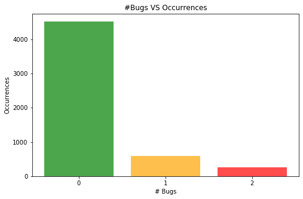

```python
unique, counts = np.unique(y, return_counts=True)
print("Classes:", unique.tolist())
print("Counts:", counts.tolist())

plt.bar(unique, counts, color=['g', 'orange', 'r'], alpha=0.7)
plt.title("#Bugs VS Occurrences")
plt.xticks(range(len(unique)))
plt.ylabel("Occurrences")
plt.xlabel("# Bugs");
```

### Note:

Based on these class balances, we have to be careful not to overfit or make the classifier favors "Class 0" unfairly

# More EDA on Training Set

### Note:

It is better to Leave-One-Out and do the EDA & some transoformational preprocessing so that we do not use our intuition and analysis from the test set and be fooled by a high accuracy on a set that we have prepared our model for.

###### Example:

Feature Selection that is done on the whole dataset is a very pure data leakage. Your test set is not a test set if the model has already known what are the best features to use as predictors of the target value

###### Example:

Dimensionality reduction (such as PCA) that is done one the whole dataset means that you have leaked distributional information from the test set to the training set (e.g. Variance).

###### Example:

Scaling the dataset as a whole is needed but when you use the whole dataset for fitting the scalar, then data leakage has occured, if a blueprint dataset factor (e.g. variance, mean, minimum, maximum) is used

```python
from sklearn.model_selection import train_test_split
X_train, X_test, y_train, y_test = train_test_split(X, y, test_size=0.3)
X_cv, X_test, y_cv, y_test = train_test_split(X_test, y_test, test_size=0.5)
print("Train:", X_train.shape, y_train.shape,
      "Test:", X_test.shape, y_test.shape,
      "Cross Validation", X_cv.shape, y_cv.shape)
```

```
Train: (3759, 17) (3759,) Test: (806, 17) (806,) Cross Validation (806, 17) (806,)
```

Let's make sure that we have a similar class balance distribution

```
Classes: [0, 1, 2]
Counts: [3175, 408, 176]
```

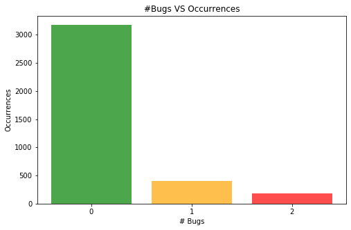

```python
unique, counts = np.unique(y_train, return_counts=True)
print("Classes:", unique.tolist())
print("Counts:", counts.tolist())

plt.bar(unique, counts, color=['g', 'orange', 'r'], alpha=0.7)
plt.title("#Bugs VS Occurrences")
plt.xticks(range(len(unique)))
plt.ylabel("Occurrences")
plt.xlabel("# Bugs");
```

##### Scaling Features

```python
X_train_scaled = pd.DataFrame(StandardScaler().fit_transform(X_train.values), columns=X_train.columns, index=X_train.index)
X_test_scaled = pd.DataFrame(StandardScaler().fit_transform(X_test.values), columns=X_test.columns, index=X_test.index)

data_for_viz = X_train_scaled.copy()
data_for_viz_unscaled = X_train.copy()

data_for_viz['Bugs'] = y_train.copy().tolist()
data_for_viz_unscaled['Bugs'] = y_train.copy().tolist()
```

```python
data_for_viz.head()
```

|  | cbo | dit | fanIn | fanOut | lcom | noc | numberOfAttributes | numberOfAttributesInherited | numberOfLinesOfCode | numberOfMethods | numberOfMethodsInherited | numberOfPrivateAttributes | numberOfPrivateMethods | numberOfPublicAttributes | numberOfPublicMethods | rfc | wmc | Bugs |
| --- | --- | --- | --- | --- | --- | --- | --- | --- | --- | --- | --- | --- | --- | --- | --- | --- | --- | --- |
| 4104 | -0.483834 | -0.724680 | -0.237909 | -0.634389 | -0.088951 | -0.220547 | -0.100117 | -0.274750 | -0.343483 | -0.530870 | -0.418399 | -0.144317 | -0.117360 | -0.047344 | -0.476868 | -0.416268 | -0.372865 | 1 |
| 1672 | 1.801626 | -0.724680 | 1.487092 | 1.558706 | 0.014475 | -0.220547 | 0.034309 | -0.274750 | 0.192729 | 0.641922 | -0.490656 | 0.825103 | 0.587739 | -0.047344 | 0.574479 | 0.662977 | 0.444984 | 0 |
| 1153 | -0.113219 | 2.241911 | -0.312909 | 0.268650 | -0.076783 | -0.220547 | -0.100117 | -0.248178 | -0.259135 | -0.185931 | 0.978583 | -0.144317 | -0.117360 | -0.047344 | -0.126419 | -0.189536 | -0.261970 | 1 |
| 1114 | -0.298526 | -0.724680 | -0.012909 | -0.634389 | -0.088951 | -0.220547 | -0.100117 | -0.274750 | -0.337458 | -0.530870 | -0.635172 | -0.144317 | -0.352394 | -0.047344 | -0.389256 | -0.398130 | -0.372865 | 0 |
| 1496 | 0.072089 | 1.500263 | -0.312909 | 0.655667 | 0.014475 | -0.220547 | -0.153888 | -0.261464 | -0.099477 | 0.641922 | 1.123098 | -0.532085 | -0.352394 | -0.047344 | 0.224030 | -0.017219 | -0.067904 | 0 |

#### Correlation Matrix

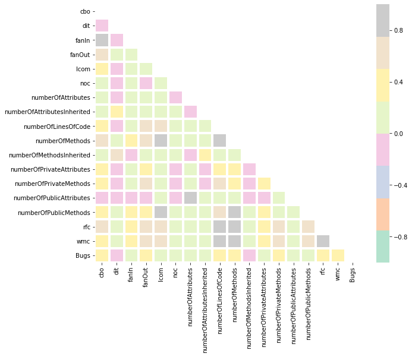

```python
fig, ax = plt.subplots(figsize=(10,8))

corr = data_for_viz.corr()
mask = np.triu(corr)
sns.heatmap(corr, vmin=-1, vmax=1, center= 0, cmap= 'Pastel2', linewidths=3, ax=ax, mask=mask);
```

###### We can see that highest correlated variables with Bugs are:

1. cbo
   - is correlated with fanIn
   - is correlated with fanOut
2. fanout
   - is correlated with wmc
   - is correlated with rfc
   - is correlated with numberOfLinesOfCode
   - is correlated with numberOfMethods
3. numberOfLinesOfCode
   - is correlated with wmc
   - is correlated with rfc
   - is correlated with numberOfMethods
4. numberOfMethods
   - is correlated with wmc
   - is correlated with rfc
   - is correlated with numberOfPublicMethods
   - .
   - .
   - .

#### To sum up: There is a high correlation between:

```
- Bugs
- cbo
- fanout
- fanIn
- wmc
- rfc
- numberOfLinesOfCode
- numberOfMethods
- numberOfPublicMethods
- numberOfPrivateMethods
```

### Feature importance with Lasso regression

```python
lasso = Lasso()
lasso.fit(X_train,y_train)
coef = pd.Series(lasso.coef_, index = X_train.columns)

print("Discarded Features:", np.sum(lasso.coef_==0), "out of", len(X_train.columns))
```

```
Discarded Features: 14 out of 17
```

```python
coef = coef[coef != 0]
```

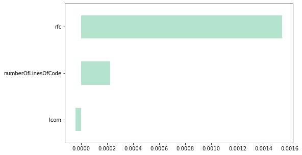

```python
coef.sort_values().plot(kind='barh', cmap="Pastel2");
```

### Feature importance with Random Forest Classifier

```python
rfc = RandomForestClassifier()
rfc.fit(X_train, y_train);
coef_rfc = pd.Series(rfc.feature_importances_, index = X_train.columns)
```

```python
preds = rfc.predict(X_train)
print("accuracy score:", accuracy_score(y_train, preds))
```

```
accuracy score: 0.9973397180101091
```

### Note:

of course, the accuracy is going to be high on the same set that was trained on, we are just making sure that it has done a good job on predicting the training set and thus giving an accurate prediction of important features **based on the training set**

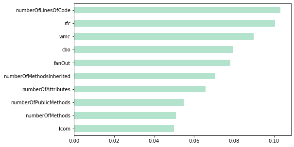

```python
coef_rfc.sort_values()[7:].plot(kind='barh', cmap="Pastel2");
```

#### Pick Features for DataViz

Let's now pick a couple of important features from our analysis with correlation matrix, lasso regression feature importance, and random forest classifier feature importance, we will go with:

```
- rfc
- cbo
- fanOut
- wmc
- numberOfLinesOfCode
```

#### As these features are the most effective ones as predictors over our analysis

# Data Visualization

```python
data_for_viz_unscaled.head()
```

[output not shown]

#### Pair Plots (Scatter)

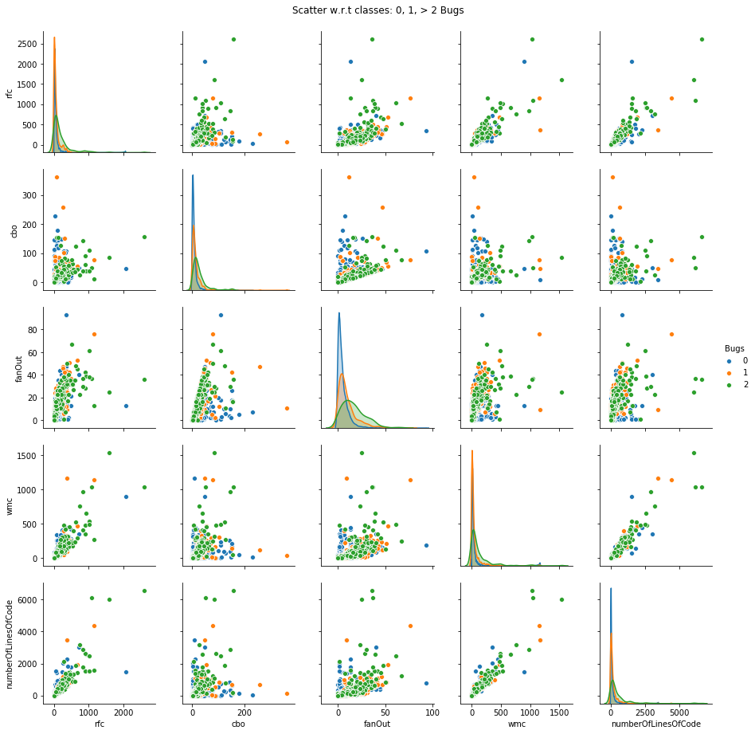

```python
for_pair_plot = data_for_viz_unscaled[['rfc', 'cbo', 'fanOut','wmc', 'numberOfLinesOfCode', 'Bugs']]
pairplot = sns.pairplot(for_pair_plot, hue="Bugs", vars=['rfc', 'cbo', 'fanOut', 'wmc', 'numberOfLinesOfCode']);
pairplot.fig.suptitle("Scatter w.r.t classes: 0, 1, > 2 Bugs", y=1.02);
```

### Kernal Density of Classes w.r.t one variable

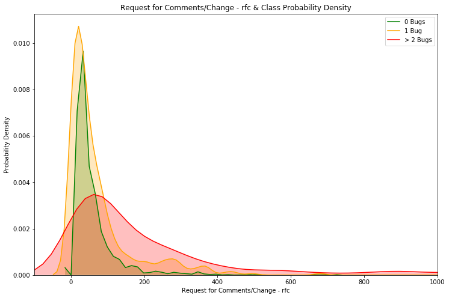

```python
fig = plt.figure(figsize=(12,8))
sns.kdeplot(data_for_viz_unscaled.loc[(data_for_viz_unscaled['Bugs'] == 0), 'rfc'], color='g', shade=True, Label='0 Bugs')
sns.kdeplot(data_for_viz_unscaled.loc[(data_for_viz_unscaled['Bugs'] == 1), 'rfc'], color='orange', shade=True, Label='1 Bug')
sns.kdeplot(data_for_viz_unscaled.loc[(data_for_viz_unscaled['Bugs'] == 2), 'rfc'], color='r', shade=True, Label='> 2 Bugs')

plt.xlabel('Request for Comments/Change - rfc')
plt.ylabel('Probability Density')
plt.title("Request for Comments/Change - rfc & Class Probability Density")

plt.xlim(-100, 1000);
```

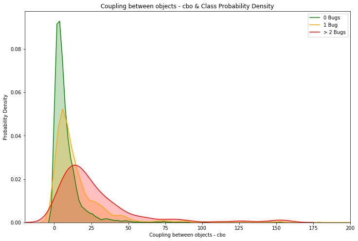

```python
fig = plt.figure(figsize=(12,8))
sns.kdeplot(data_for_viz_unscaled.loc[(data_for_viz_unscaled['Bugs'] == 0), 'cbo'], color='g', shade=True, Label='0 Bugs')
sns.kdeplot(data_for_viz_unscaled.loc[(data_for_viz_unscaled['Bugs'] == 1), 'cbo'], color='orange', shade=True, Label='1 Bug')
sns.kdeplot(data_for_viz_unscaled.loc[(data_for_viz_unscaled['Bugs'] == 2), 'cbo'], color='r', shade=True, Label='> 2 Bugs')

plt.xlabel('Coupling between objects - cbo')
plt.ylabel('Probability Density')
plt.title("Coupling between objects - cbo & Class Probability Density")

plt.xlim(-20, 200);
```

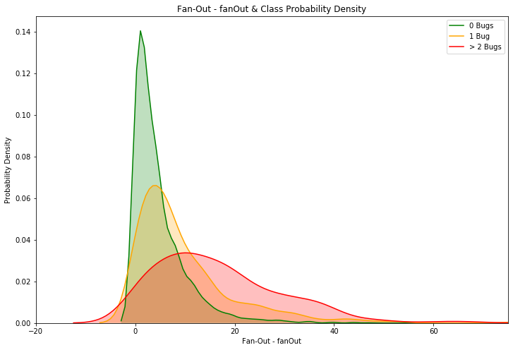

```python
fig = plt.figure(figsize=(12,8))
sns.kdeplot(data_for_viz_unscaled.loc[(data_for_viz_unscaled['Bugs'] == 0), 'fanOut'], color='g', shade=True, Label='0 Bugs')
sns.kdeplot(data_for_viz_unscaled.loc[(data_for_viz_unscaled['Bugs'] == 1), 'fanOut'], color='orange', shade=True, Label='1 Bug')
sns.kdeplot(data_for_viz_unscaled.loc[(data_for_viz_unscaled['Bugs'] == 2), 'fanOut'], color='r', shade=True, Label='> 2 Bugs')

plt.xlabel('Fan-Out - fanOut')
plt.ylabel('Probability Density')
plt.title("Fan-Out - fanOut & Class Probability Density")

plt.xlim(-20, 75);
```

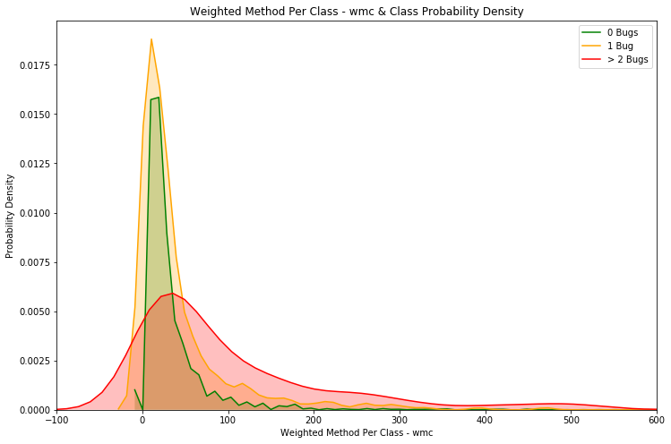

```python
fig = plt.figure(figsize=(12,8))
sns.kdeplot(data_for_viz_unscaled.loc[(data_for_viz_unscaled['Bugs'] == 0), 'wmc'], color='g', shade=True, Label='0 Bugs')
sns.kdeplot(data_for_viz_unscaled.loc[(data_for_viz_unscaled['Bugs'] == 1), 'wmc'], color='orange', shade=True, Label='1 Bug')
sns.kdeplot(data_for_viz_unscaled.loc[(data_for_viz_unscaled['Bugs'] == 2), 'wmc'], color='r', shade=True, Label='> 2 Bugs')

plt.xlabel('Weighted Method Per Class - wmc')
plt.ylabel('Probability Density')
plt.title("Weighted Method Per Class - wmc & Class Probability Density")

plt.xlim(-100, 600);
```

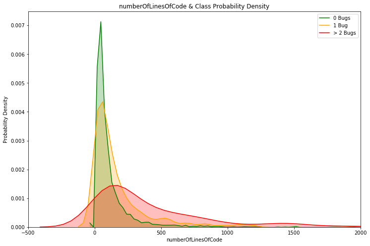

```python
fig = plt.figure(figsize=(12,8))
sns.kdeplot(data_for_viz_unscaled.loc[(data_for_viz_unscaled['Bugs'] == 0), 'numberOfLinesOfCode'], color='g', shade=True, label='0 Bugs')
sns.kdeplot(data_for_viz_unscaled.loc[(data_for_viz_unscaled['Bugs'] == 1), 'numberOfLinesOfCode'], color='orange', shade=True, label='1 Bug')
sns.kdeplot(data_for_viz_unscaled.loc[(data_for_viz_unscaled['Bugs'] == 2), 'numberOfLinesOfCode'], color='r', shade=True, label='> 2 Bugs')

plt.xlabel('numberOfLinesOfCode')
plt.ylabel('Probability Density')
plt.title("numberOfLinesOfCode & Class Probability Density")
plt.xlim(-500, 2000);
```

#### Scatter 3D Cross Plot

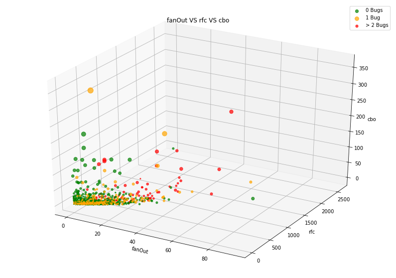

```python
fig = plt.figure(figsize=(14,10))
ax = fig.gca(projection='3d')

ax.scatter(data_for_viz_unscaled[data_for_viz_unscaled['Bugs'] == 0]['fanOut'],
           data_for_viz_unscaled[data_for_viz_unscaled['Bugs'] == 0]['rfc'],
           data_for_viz_unscaled[data_for_viz_unscaled['Bugs'] == 0]['cbo'], c='g',
           s=data_for_viz_unscaled[data_for_viz_unscaled["Bugs"] == 0]['cbo']/3, alpha=0.7, label='0 Bugs')

ax.scatter(data_for_viz_unscaled[data_for_viz_unscaled['Bugs'] == 1]['fanOut'],
           data_for_viz_unscaled[data_for_viz_unscaled['Bugs'] == 1]['rfc'],
           data_for_viz_unscaled[data_for_viz_unscaled['Bugs'] == 1]['cbo'],
           s=data_for_viz_unscaled[data_for_viz_unscaled["Bugs"] == 1]['cbo']/3, alpha=0.7, c='orange', label='1 Bug')

ax.scatter(data_for_viz_unscaled[data_for_viz_unscaled['Bugs'] == 2]['fanOut'],
           data_for_viz_unscaled[data_for_viz_unscaled['Bugs'] == 2]['rfc'],
           data_for_viz_unscaled[data_for_viz_unscaled['Bugs'] == 2]['cbo'],
           s=data_for_viz_unscaled[data_for_viz_unscaled["Bugs"] == 2]['cbo']/3, alpha=0.7, c='r', label='> 2 Bugs')
ax.legend()

ax.set_xlabel('fanOut')
ax.set_ylabel('rfc')
ax.set_zlabel('cbo')
ax.set_title("fanOut VS rfc VS cbo");
```

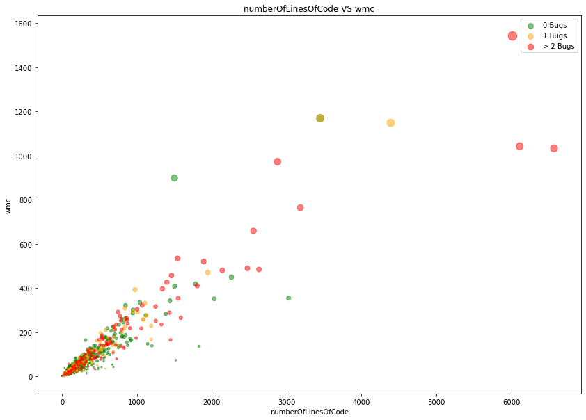

```python
plt.figure(figsize=(14,10))
plt.scatter(data_for_viz_unscaled[data_for_viz_unscaled["Bugs"] == 0]['numberOfLinesOfCode'],
            data_for_viz_unscaled[data_for_viz_unscaled["Bugs"] == 0]['wmc'], label='0 Bugs',
            s=data_for_viz_unscaled[data_for_viz_unscaled["Bugs"] == 0]['wmc']/10, c='g',
           alpha=0.5)

plt.scatter(data_for_viz_unscaled[data_for_viz_unscaled["Bugs"] == 1]['numberOfLinesOfCode'],
            data_for_viz_unscaled[data_for_viz_unscaled["Bugs"] == 1]['wmc'], label='1 Bugs',
            s=data_for_viz_unscaled[data_for_viz_unscaled["Bugs"] == 1]['wmc']/10, c='orange',
           alpha=0.5)

plt.scatter(data_for_viz_unscaled[data_for_viz_unscaled["Bugs"] == 2]['numberOfLinesOfCode'],
            data_for_viz_unscaled[data_for_viz_unscaled["Bugs"] == 2]['wmc'], label='> 2 Bugs',
            s=data_for_viz_unscaled[data_for_viz_unscaled["Bugs"] == 2]['wmc']/10, c='r',
           alpha=0.5)

plt.legend()
plt.xlabel('numberOfLinesOfCode')
plt.ylabel('wmc')
plt.title("numberOfLinesOfCode VS wmc");
```

[figure not shown]

```python
fig = plt.figure(figsize=(10,6))


ax = sns.barplot(x="Bugs", y="rfc", data=for_pair_plot, alpha=0.7, palette=['g', 'orange', 'r'])
plt.title("Bugs & numberOfLinesOfCode");
```

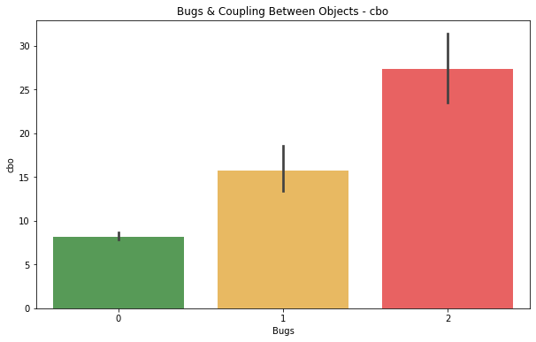

```python
fig = plt.figure(figsize=(10,6))
ax = sns.barplot(x="Bugs", y="cbo", data=for_pair_plot, alpha=0.7, palette=['g', 'orange', 'r'])
plt.title("Bugs & Coupling Between Objects - cbo");
```

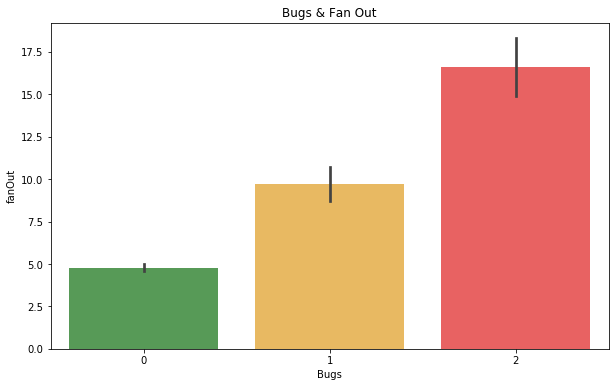

```python
fig = plt.figure(figsize=(10,6))
ax = sns.barplot(x="Bugs", y="fanOut", data=for_pair_plot, alpha=0.7, palette=['g', 'orange', 'r'])
plt.title("Bugs & Fan Out");
```

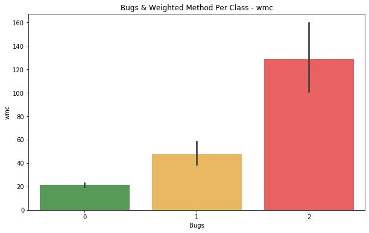

```python
fig = plt.figure(figsize=(10,6))
ax = sns.barplot(x="Bugs", y="wmc", data=for_pair_plot, alpha=0.7, palette=['g', 'orange', 'r'])
plt.title("Bugs & Weighted Method Per Class - wmc");
```

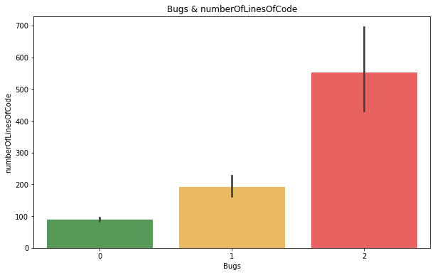

```python
fig = plt.figure(figsize=(10,6))
ax = sns.barplot(x="Bugs", y="numberOfLinesOfCode", data=for_pair_plot, alpha=0.7, palette=['g', 'orange', 'r'])
plt.title("Bugs & numberOfLinesOfCode");
```

## Observation:

It is very clear from all the plots above that the larger the number of negative properties (not necessarily negative but intuitively relates to a risk prone or a bug susceptible software property) the larger the probability of having more bugs.

# Clustering Analysis

### UMAP Dimensionality reduction algorithm

This is an alogorithm that was developed in 2018 which competes with state-of-the-art dimensionality reduction algorithms in its fast execution performance and the ability to project the dimensions without losing a lot of information.

Feel free to explore benchmarking against other algorithms here: https://umap-learn.readthedocs.io/en/latest/benchmarking.html

*McInnes, Leland, Healy, John, & James. (2018, December 06). UMAP: Uniform Manifold Approximation and Projection for Dimension Reduction. Retrieved from https://arxiv.org/abs/1802.03426*

```python
reducer = umap.UMAP(verbose=False)
embedding = reducer.fit_transform(X_train_scaled)
embedding.shape
```

```
(3759, 2)
```

```python
embedding = pd.DataFrame(embedding)
embedding.head()
```

|  | 0 | 1 |
| --- | --- | --- |
| 0 | -1.001042 | -3.540053 |
| 1 | -0.425117 | -4.456758 |
| 2 | -1.808464 | -4.692741 |
| 3 | 0.311770 | -1.891203 |
| 4 | 8.122357 | -3.292733 |

#### Next plot is colored by K-Means predictions

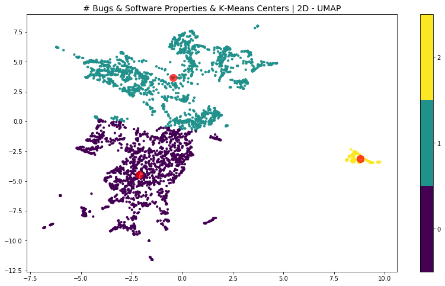

```python
kmeans_umap = KMeans(n_clusters=3)
kmeans_umap.fit(embedding)
preds_kmeans_umap = kmeans_umap.predict(embedding)

fig, ax = plt.subplots(figsize=(14,8))

plt.scatter(embedding[0], embedding[1], c=preds_kmeans_umap, s=10, cmap='viridis')
cbar = plt.colorbar(boundaries=np.arange(4)-0.5)
cbar.set_ticks(np.arange(3))
cbar.set_ticklabels(np.unique(preds_kmeans_umap))

plt.scatter(kmeans_umap.cluster_centers_[:, 0], kmeans_umap.cluster_centers_[:, 1], c='red', s=150, alpha=0.7);

plt.title('# Bugs & Software Properties & K-Means Centers | 2D - UMAP', fontsize=14);
```

```python
print("K-Means Accuracy Score:", accuracy_score(preds_kmeans_umap, y_train))
```

```
K-Means Accuracy Score: 0.48417132216014896
```

### Note:

This accuracy on the training set is not a surprise! Take a look at the plot below.

Note that there is no relationship between the number of bugs and the clusters set by K-Means predictor. 0,1, and 2 in the plot are just the specified number of clusters for K-Means.

To clarify the confusion

#### Next Plot is colored by actual values (y_train) and K-Means centers are included

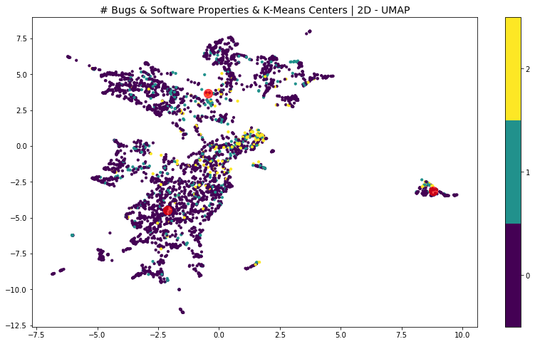

```python
fig, ax = plt.subplots(figsize=(14,8))

plt.scatter(embedding[0], embedding[1], c=y_train, s=10, cmap='viridis')
cbar = plt.colorbar(boundaries=np.arange(4)-0.5)
cbar.set_ticks(np.arange(3))
cbar.set_ticklabels(np.unique(y_train))

plt.scatter(kmeans_umap.cluster_centers_[:, 0], kmeans_umap.cluster_centers_[:, 1], c='red', s=150, alpha=0.7);

plt.title('# Bugs & Software Properties & K-Means Centers | 2D - UMAP', fontsize=14);
```

### PCA Dimensionality reduction algorithm

#### Next plot is colored by actual values (y_train)

#### Note:

The plot was zoomed due to extreme outliers

```python
pca = PCA(n_components=2)
principalComponents = pca.fit_transform(X_train)

principalComponents = pd.DataFrame(principalComponents)
```

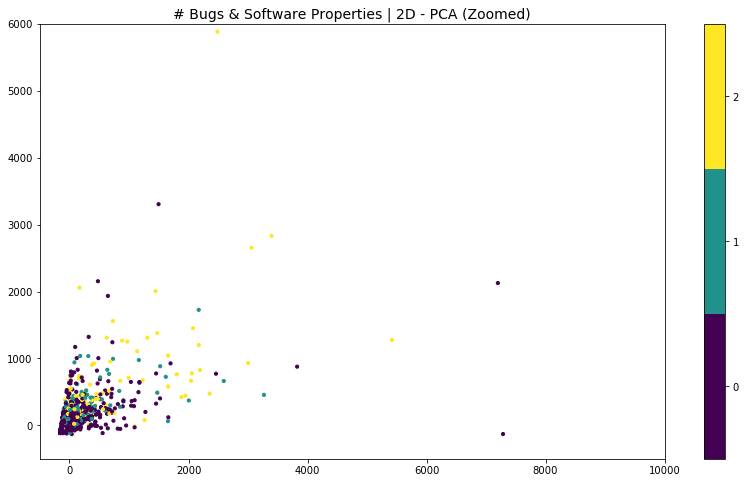

```python
fig, ax = plt.subplots(figsize=(14,8))

plt.scatter(principalComponents[0], principalComponents[1], c=y_train, s=10, cmap='viridis')
cbar = plt.colorbar(boundaries=np.arange(4)-0.5)
cbar.set_ticks(np.arange(3))
cbar.set_ticklabels(np.unique(y_train))
ax.set_xlim(-500, 10000);
ax.set_ylim(-500, 6000);

plt.title('# Bugs & Software Properties | 2D - PCA (Zoomed)', fontsize=14);
```

#### Next Plot is colored by K-Means cluster predictions and not actual values (y_train)

```
K-Means Accuracy Score Using PCA: 0.8480978983772279
```

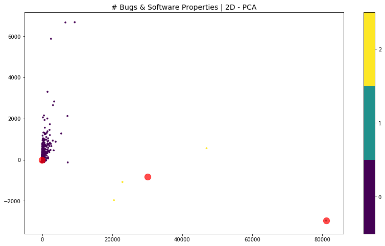

```python
kmeans_pca = KMeans(n_clusters=3)
kmeans_pca.fit(principalComponents)
preds_kmeans_pca = kmeans_pca.predict(principalComponents)

fig, ax = plt.subplots(figsize=(14,8))

plt.scatter(principalComponents[0], principalComponents[1], c=preds_kmeans_pca, s=7, cmap='viridis')
cbar = plt.colorbar(boundaries=np.arange(4)-0.5)
cbar.set_ticks(np.arange(3))
cbar.set_ticklabels(np.unique(preds_kmeans_pca))

plt.scatter(kmeans_pca.cluster_centers_[:, 0], kmeans_pca.cluster_centers_[:, 1], c='red', s=150, alpha=0.7);

# ax.set_xlim(-500, 10000);
# ax.set_ylim(-500, 6000);

plt.title('# Bugs & Software Properties | 2D - PCA', fontsize=14);

print("K-Means Accuracy Score Using PCA:", accuracy_score(preds_kmeans_pca, y_train))
```

### Note

It is obvious to spot that K-Means had a high accuracy on the training set but definitely not a generalizable one not just because it's on the training set but mainly, for our analysis, it has almost excluded a whole class (**Recall: Notes on class balances in the dataset**) if we took a look at the actualy distribution of classes when if was plotted by actual values after PCA reduction and now with the predicted values from K-Means

# Modeling

#### Models:

- For Multi-Class Classification
  - Random Forest Classifier (Ensemble)
  - K-Nearest Neighbor
  - K-Means (Clustering)
- For Binary Classification
  - AdaBoost (Boosting)
  - Support-Vector Machine
  - Bagging Classifier
- Neural Network (FCNN)

All of these models either:

- need scaling for better generalized results (i.e. SVC, KNN, KMeans, FCNN) as they are distance-based where they are affected by outliers and more importantly (in our case) might favor one feature against another.
- not affected by scaling if the weak learner is a tree-based classifier for AdaBoost, Bagging, or RFC

#### Scale Features seperately in each dataset (NOT the cross validation one; cv dataset should be scaled with each fold in hyper-parameter tuning)

```python
X_train_scaled = pd.DataFrame(StandardScaler().fit_transform(X_train.values), columns=X_train.columns, index=X_train.index)
X_test_scaled = pd.DataFrame(StandardScaler().fit_transform(X_test.values), columns=X_test.columns, index=X_test.index)

print("Train:", X_train.shape, y_train.shape,
      "Test:", X_test.shape, y_test.shape,
      "Cross Validation", X_cv.shape, y_cv.shape)
```

```
Train: (3759, 17) (3759,) Test: (806, 17) (806,) Cross Validation (806, 17) (806,)
```

#### Modeling Function

```python
def Modeler(model, X_train, y_train, X_cv, y_cv, params, scale=True, n_jobs=True, pca=False):

    if scale & pca:
        pipeline = Pipeline([
            ('scale', StandardScaler()),
            ('dim_reduct', PCA(n_components=4)),
            ('clf', model())])
        print("Scaling and dim reduct...")

    elif scale:
        pipeline = Pipeline([ ('scale', StandardScaler()), ('clf', model())])

    elif pca:
        pipeline = Pipeline([
        ('dim_reduct', PCA(n_components=pca)),
        ('clf', model())])
    else:
        pipeline = Pipeline([('clf', model())])

    grid = GridSearchCV(pipeline, param_grid = params, cv=3, n_jobs=4, refit=True)
    grid.fit(X_cv, y_cv)

    best_prameters = {}
    for k, v in grid.best_params_.items():
        best_prameters[k[5:]] = v

    if n_jobs:
        model = model(**best_prameters, n_jobs=4)
    else:
        model = model(**best_prameters)

    model.fit(X_train, y_train)

    print("Best Parameters for model:", best_prameters)

    return {
        "model": model,
        "best_params":best_prameters
    }
```

#### Note

- We will value all classes in the same way without any dominance from one class on the metric. Therefore, we will use Macro-Averaging for both ROC and F1-Score. This will tell us that our scores will be much lower than expected due to the imbalance (**More details on that at the end**) Event though that ROC is no that sensitive to imbalances, F1-Score can help us a lot here
- We can use AUCROC by one-vs-all Technique

```python
def model_eval(model, X_test, y_test, acc=True, auc_=True, plot_conf=True, plot_auc=True, multi=True, f1=True, prop=False):

    res = [None, None, None] # Accuracy, auc_roc, f1_score
    y_pred = model.predict(X_test)

    if prop:
        y_pred = np.where(y_pred > 0.5, 1, 0)

    if f1:
        f_sc = f1_score(y_test, y_pred, average='macro')
        res[2] = f_sc

    if acc:
        res[0] = accuracy_score(y_test, y_pred)
#         print('accuracy:', res[0] * 100 ,'%')

    if auc_:
        lb = LabelBinarizer()
        lb.fit(y_test)

        truth = lb.transform(y_test)
        y_pred_encode = lb.transform(y_pred)

        res[1] = roc_auc_score(truth, y_pred_encode, average = 'macro')
#         print('ROC:', res[1] * 100 ,'%')

    if plot_conf:
        fig, ax = plt.subplots(figsize=(10,6))

        conf = confusion_matrix(y_test, y_pred, labels=np.unique(y_test))
        sns.heatmap(conf, cmap= 'Set1', annot=True, cbar=False)
        plt.ylabel('Actual')
        plt.xlabel('Predicted')
        plt.title('Confusion Matrix');

    if plot_auc:
        fig, ax = plt.subplots(figsize=(10,6))

        if not auc_:
            lb = LabelBinarizer()
            lb.fit(y_test)

            truth = lb.transform(y_test)
            y_pred_encode = lb.transform(y_pred)

        fpr = [None, None, None]
        tpr = [None, None, None]
        auc_of_roc = [None, None, None]

        n_classes = 1 #(0, 1)
        if multi:
            n_classes = 3

        for i in range(n_classes):
            fpr[i], tpr[i], _ = roc_curve(truth[:, i], y_pred_encode[:, i])
            auc_of_roc[i] = auc(fpr[i], tpr[i])

        plt.plot(fpr[0], tpr[0], label='0 - area under ROC = %0.3f' % auc_of_roc[0])
        if multi:
            plt.plot(fpr[1], tpr[1], label='1 - area under ROC = %0.3f' % auc_of_roc[1])
            plt.plot(fpr[2], tpr[2], label='2 - area under ROC = %0.3f' % auc_of_roc[2])

        plt.xlabel('False Positive Rate')
        plt.ylabel('True Positive Rate')
        plt.title("ROC AUC");
        plt.legend()

    return res
```

#### Under Sampler Function

```python
def under_sample(X_train, y_train, n=573):
    train_ = pd.concat([X_train, y_train], axis=1)
    df_0 = train_[train_.iloc[:, -1] == 0].sample(n= n)
    df_1 = train_[train_.iloc[:, -1] == 1].sample(n= n)

    train_ = pd.concat([df_0, df_1], axis=0).sample(frac=1.0)
    X_train_under_sampled = train_.iloc[:, 0:-1]
    y_train_under_sampled = train_.iloc[:, -1]
    return X_train_under_sampled, y_train_under_sampled
```

## Base-Line Classifier

We have to give a better accuracy, roc, or f1-score if we want our classifier to be better than a mere guessing

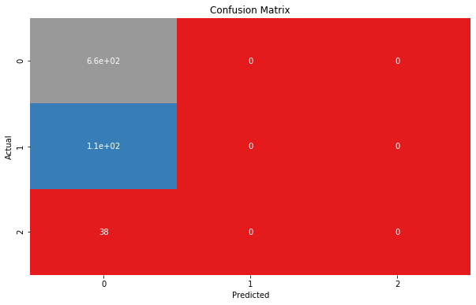

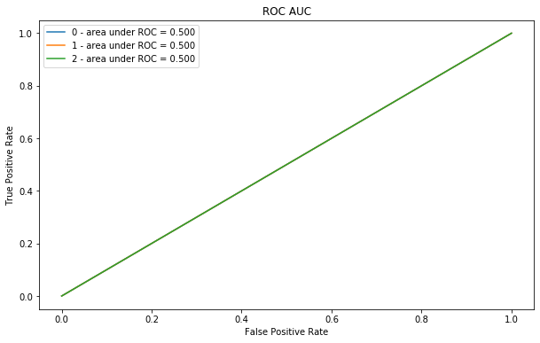

```python
dmc = DummyClassifier(strategy="most_frequent")
dmc.fit(X_train_scaled, y_train)

model_scoring = model_eval(dmc, X_test_scaled, y_test)

scores = {}
scores["Dummy Classifier | Multi"] = {"Accuracy": model_scoring[0],
                             "ROC": model_scoring[1],
                             "F1-Score": model_scoring[2]}
```

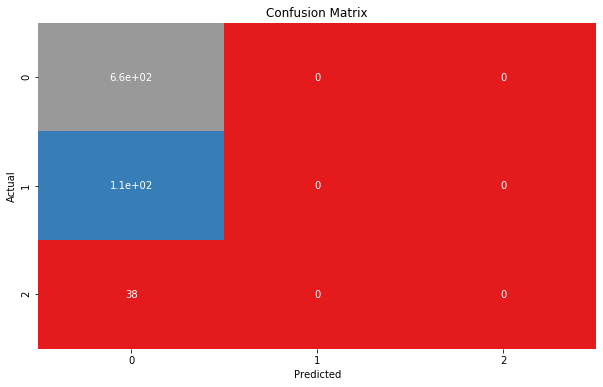

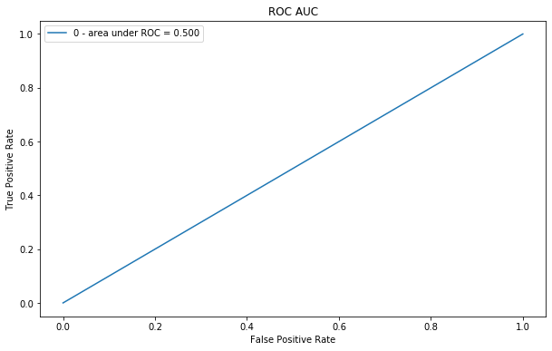

```python
dmc = DummyClassifier(strategy="most_frequent")
dmc.fit(X_train_scaled, y_train)

model_scoring = model_eval(dmc, X_test_scaled, y_test, multi=False)

scores["Dummy Classifier | Binary"] = {"Accuracy": model_scoring[0],
                             "ROC": model_scoring[1],
                             "F1-Score": model_scoring[2]}
```

## Multi-Classifiers

### Random Forest Classifier

```python
rfc_params = {
    'clf__n_estimators'      : [200, 500, 1000],
    'clf__max_depth'         : [10, 20, 50],
    'clf__max_features': [1.0, 0.7, 0.4],
    'clf__criterion' :['gini', 'entropy']
}

rfc = Modeler(RandomForestClassifier, X_train_scaled, y_train, X_cv, y_cv, rfc_params, scale=True)
```

```
Best Parameters for model: {'criterion': 'entropy', 'max_depth': 50, 'max_features': 0.4, 'n_estimators': 500}
```

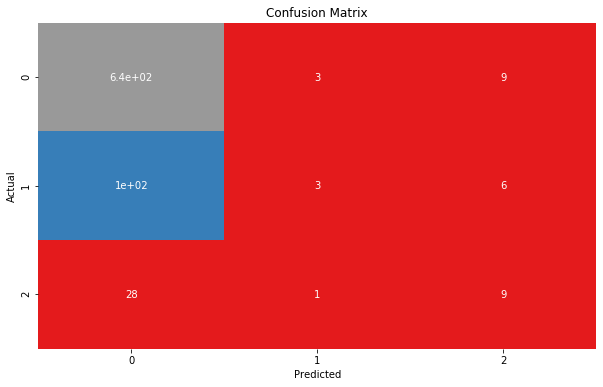

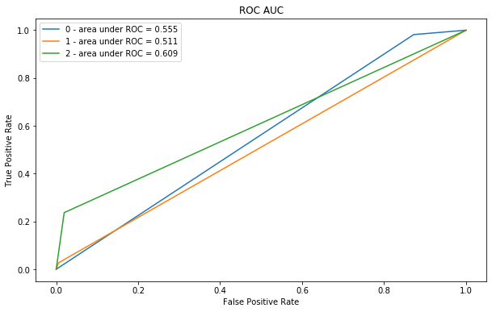

```python
model_scoring = model_eval(rfc["model"], X_test_scaled, y_test)
scores["Random Forest | Multi"] = {"Accuracy": model_scoring[0],
                             "ROC": model_scoring[1],
                             "F1-Score": model_scoring[2]}
```